# HPMT 5335 - Assignment 1

Evan Munro and Jeremy Yeatts

2/11/2021

# Prompt

**"Please refer to the ‘birth’ data in the package catdata. In the birth data, each observation is one birth. The description and the data dictionary of the ‘birth’ data can be found on the page 7 and 8 in the document https://cran.r-project.org/web/packages/catdata/catdata.pdf.**

**Using R to answer the following questions (You need to provide your code and the results). You will need to submit two files. One file is your R script (.R format), which contains all your codes to answer the questions below. The other file is a document file (.doc, .docx, .pdf format), which are the copy-and-paste results from R. Please submit the two files to Blackboard by the due date."**

## **Question 1 (20 points):**

#### **The observations in the data are from 20 different countries, including France (FR), Belgium (BE), Canada (CA), Switzerland (CH), Great Britain (GB), and United States (US), etc.**

Loading data:

```r
library(catdata)
library(dplyr)
data(birth)
str(birth)
```

```
## 'data.frame':    775 obs. of  25 variables:
##  $ IndexMother : int  13 114 114 349 582 599 270 16 572 49 ...
##  $ Sex         : int  1 1 1 1 1 2 1 1 1 2 ...
##  $ Weight      : int  3980 3630 3240 2630 2940 3670 3460 2970 2730 2275 ...
##  $ Height      : num  52 51.5 48 46 48 49 50 48.5 46.5 46 ...
##  $ Head        : num  36 35.5 34 NA 34 33.5 NA 34 NA NA ...
##  $ Month       : int  8 11 3 5 5 4 6 2 8 8 ...
##  $ Year        : int  2003 2002 2004 2001 2002 2004 2003 2004 2000 2001 ...
##  $ Country     : Factor w/ 20 levels "AFRIQUESUD","BE",..: 5 8 8 8 8 8 8 8 8 8 ...
##  $ Term        : int  40 39 40 36 39 41 39 38 36 37 ...
##  $ AgeMother   : int  24 29 31 21 25 28 22 24 30 22 ...
##  $ Previous    : int  0 0 1 0 0 0 0 0 0 0 ...
##  $ WeightBefore: num  65 51 46 60 73 50 60 48 75 45 ...
##  $ HeightMother: int  171 163 163 157 161 155 170 163 175 161 ...
##  $ WeightEnd   : num  77 56.5 51.5 80 82 64.5 82 59 92 57 ...
##  $ Twins       : int  0 0 0 0 0 0 0 0 0 0 ...
##  $ Intensive   : int  0 0 0 0 5 0 0 0 3 0 ...
##  $ Cesarean    : int  0 1 1 0 0 0 0 1 0 0 ...
##  $ Planned     : int  NA 0 0 NA NA NA NA 0 NA NA ...
##  $ Episiotomy  : int  1 NA NA 0 0 0 1 NA 1 1 ...
##  $ Tear        : int  1 NA NA 0 0 1 0 NA 0 0 ...
##  $ Operative   : int  0 NA NA 0 0 0 0 NA 0 0 ...
##  $ Induced     : int  0 0 0 1 0 0 0 0 0 0 ...
##  $ Membranes   : int  0 1 0 1 0 1 0 0 0 1 ...
##  $ Rest        : int  0 0 0 1 0 0 0 0 1 1 ...
##  $ Presentation: int  1 3 3 1 1 1 1 1 1 2 ...
```

### **(1)**

#### **Find the number of observations for each country. (Hint: use table())**

```r
# table converted to data frame because output is easier to read
data.frame(table(birth$Country, dnn = "Country"))
```

```
##       Country Freq
## 1  AFRIQUESUD    1
## 2          BE   73
## 3          CA   32
## 4          CH   12
## 5          DE    2
## 6          ES    3
## 7          FI    1
## 8          FR  627
## 9          GB    7
## 10         GR    1
## 11         IR    2
## 12         IT    1
## 13         LI    1
## 14         LU    1
## 15         MO    1
## 16         NL    1
## 17       OMAN    1
## 18  SINGAPORE    1
## 19        TCH    2
## 20         US    5
```

### **(2)**

#### **Assign the results in (1) to a data frame object named “country_freq”. In the data frame “country_freq”, each country is the observation. There are two variables in the data “country freq”. The first variable is named “Country”, which contains the name of the country of each observation. The second variable is named “Freq”, which contains the number of observations for each country in the birth data. (Hint: to create a data frame, use data.frame() or tbl_df() in the package dplyr. To rename the column names, use the function rename() in the package dplyr.)**

```r
country_freq = data.frame(table(birth$Country, dnn = "Country"))
country_freq
```

```
##       Country Freq
## 1  AFRIQUESUD    1
## 2          BE   73
## 3          CA   32
## 4          CH   12
## 5          DE    2
## 6          ES    3
## 7          FI    1
## 8          FR  627
## 9          GB    7
## 10         GR    1
## 11         IR    2
## 12         IT    1
## 13         LI    1
## 14         LU    1
## 15         MO    1
## 16         NL    1
## 17       OMAN    1
## 18  SINGAPORE    1
## 19        TCH    2
## 20         US    5
```

### **(3)**

#### **Reorder “country_freq” by variable “Freq” in descending order. (Hint: use arrange() in the package dplyr). Which country have the most number of observations?**

```r
country_freq = arrange(country_freq, desc(Freq))
country_freq
```

```
##       Country Freq
## 1          FR  627
## 2          BE   73
## 3          CA   32
## 4          CH   12
## 5          GB    7
## 6          US    5
## 7          ES    3
## 8          DE    2
## 9          IR    2
## 10        TCH    2
## 11 AFRIQUESUD    1
## 12         FI    1
## 13         GR    1
## 14         IT    1
## 15         LI    1
## 16         LU    1
## 17         MO    1
## 18         NL    1
## 19       OMAN    1
## 20  SINGAPORE    1
```

France has the most observations of any country with 627.

### **(4)**

#### **Plot a bar plot to show the number of observations for the country France (FR), Belgium (BE), Switzerland (CH) and Canada (CA) in the birth data. The x-axis represents countries, and the y-axis represents number of observations. Set up the name of the plot to be “Number of observations by country”, the y-axis limits to range from 0 to 700, and the color of the bar to be green. (Hint: use barplot() to plot a bar plot.)**

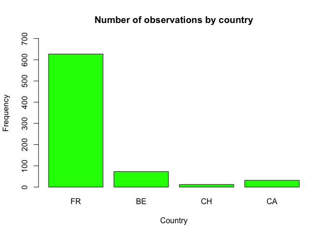

```r
birthTable = table(birth$Country)
selectColumns = c(birthTable["FR"], birthTable["BE"], birthTable["CH"], birthTable["CA"])
barplot(selectColumns,
        main="Number of observations by country",
        xlab="Country",
        ylab="Frequency",
        ylim=c(0,700),
        col="green")
```

## **Question 2 (35 points):**

#### **For Question 2, use only the “birth” data where the country of birth is France (FR).**

### **(1)**

#### **Assign a new data frame object named “birth_fr”, which is the subset of the “birth” data where the country of birth is France. What is the number of observations in data frame “birth_fr”? (Hint: to subset a data, use filter() in package dplyr)**

```r
birth_fr = filter(birth,  birth$Country == "FR")
nrow(birth_fr)
```

```
## [1] 627
```

There are 627 observations in data frame `birth_fr`.

### **(2)**

#### **We are now interested in moms’ age on the day of birth. Before analyzing the data, we found out that some of the observations have missing values (NA) in the variable “AgeMother”. Remove the observations with missing values in the variable “AgeMother” in “birth_fr”. Now, what is the number of observations in data frame “birth_fr”? (Hint: to subset a data, use filter() in package “dplyr”. Use !is.na() to remove the observations with missing values in variable “AgeMother”.)**

```r
colSums(is.na(birth_fr))
```

```
##  IndexMother          Sex       Weight       Height         Head        Month
##            0            0            0            0          120            0
##         Year      Country         Term    AgeMother     Previous WeightBefore
##            0            0            3            1            0            0
## HeightMother    WeightEnd        Twins    Intensive     Cesarean      Planned
##            0            0            0            2            0          506
##   Episiotomy         Tear    Operative      Induced    Membranes         Rest
##          121          121          121           29            0            1
## Presentation
##            3
```

```r
birth_fr = filter(birth_fr, !is.na(AgeMother))
nrow(birth_fr)
```

```
## [1] 626
```

There are now 626 observations when the row with an NA in the column ‘AgeMother’ is removed.

### **(3)**

#### **Find the mean, median, mode, minimum, maximum, 1st quartile, 3rd quartile, variance, median absolute deviation, and standard deviation of mothers’ age in the data frame “birth_fr”. (Hint: use the basic statistics functions built in R)**

```r
mean(birth_fr$AgeMother) # mean
```

```
## [1] 27.08786
```

```r
median(birth_fr$AgeMother) # median
```

```
## [1] 27
```

```r
Modes <- function(x) { # function to calculate mode(s)
  ux <- unique(x)
  tab <- tabulate(match(x, ux))
  ux[tab == max(tab)]
}
Modes(birth_fr$AgeMother) # mode
```

```
## [1] 26
```

```r
min(birth_fr$AgeMother) # minimum
```

```
## [1] 17
```

```r
max(birth_fr$AgeMother) # maximum
```

```
## [1] 42
```

```r
quantile(birth_fr$AgeMother, prob = 0.75) # 3rd quartile
```

```
##   75%
## 29.75
```

```r
var(birth_fr$AgeMother) # variance
```

```
## [1] 15.87227
```

```r
mad(birth_fr$AgeMother) # median absolute deviation
```

```
## [1] 4.4478
```

```r
sd(birth_fr$AgeMother) # standard deviation
```

```
## [1] 3.984002
```

### **(4)**

#### **Find the number of observations and the mean of mothers’ age for each year from 1998 through 2004 in the data frame “birth_fr”. Assign the results to a new data frame object “year_birth_fr” with the column names “count” and “avg_mom_age”, respectively. (Hint: use filter() to subset the “birth” data in which the values of the variable “year” are from 1998 to 2004. Use group_by() and summarize() to find the number of births and the mean of mothers’ age for each year.)**

```r
birth_fr %>%
  filter(Year >= 1998 & Year <= 2004) %>%
  group_by(Year) %>%
  summarize(count = n(), avg_mom_age = mean(AgeMother)) -> year_birth_fr
year_birth_fr
```

```
## # A tibble: 7 x 3
##    Year count avg_mom_age
## * <int> <int>       <dbl>
## 1  1998    15        27.6
## 2  1999    16        26.4
## 3  2000    29        27.4
## 4  2001    57        26.4
## 5  2002    64        26.2
## 6  2003   206        27.2
## 7  2004   205        27.7
```

### **(5)**

#### **Plot a line plot with the points on the line to show the trend of the mean mothers’ age. The x-axis represents year from 1998 through 2004, and the y-axis represents the mean of mothers’ age. Set up the name of the plot to be “Average moms’ age by year in France”, the y-axis limits to range from 20 to 28, the label of x to be Year, the label of y to be Age, the color of line to be blue and the width of line to be 2. (Hint: use plot(x, type = “o”))**

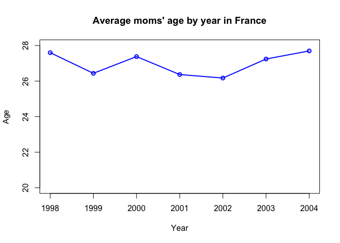

```r
plot(year_birth_fr$Year, year_birth_fr$avg_mom_age,
     type = "o",
     xlab = "Year",
     ylab = "Age",
     main = "Average moms' age by year in France",
     col = "blue",
     lwd = 2,
     ylim = c(20, 28))
```

## **Question 3 (45 points):**

#### **For Question 3, use only the data “birth_fr” in Question 2.**

### **(1)**

#### **We are now interested in babies’ gestational age (variable “Term”) in the data “birth_fr”. Some of the observations have missing values (NA) in the variable “Term”. Remove the observations with missing values in the variable “Term” in “birth_fr”. Now, what is the number of observations in data frame “birth_fr”?**

```r
colSums(is.na(birth_fr))
```

```
##  IndexMother          Sex       Weight       Height         Head        Month
##            0            0            0            0          119            0
##         Year      Country         Term    AgeMother     Previous WeightBefore
##            0            0            2            0            0            0
## HeightMother    WeightEnd        Twins    Intensive     Cesarean      Planned
##            0            0            0            2            0          505
##   Episiotomy         Tear    Operative      Induced    Membranes         Rest
##          121          121          121           29            0            1
## Presentation
##            3
```

```r
birth_fr = filter(birth_fr, !is.na(Term))
nrow(birth_fr)
```

```
## [1] 624
```

There are now 624 observations in the data frame after removing the row with an NA value in the “AgeMother” column in Question 2 and removing the rows with NA values in the “Term” column. ***

### **(2)**

#### **Plot a histogram to show the distribution of “Term” in “birth_fr”. In this histogram, x-axis is Term and y-axis is Frequency. Set up the breaks to be (26, 28, 30, 32, 34, 36, 38, 40, 42) and the x-axis tick marks to be (26, 28, 30, 32, 34, 36, 38, 40, 42) as well. (Hint: use hist() to plot a histogram and axis() to customize the tick marks on x-axis)**

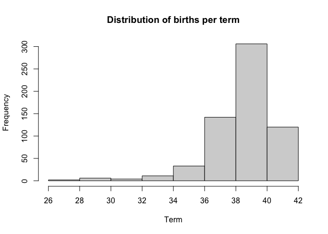

```r
{hist(birth_fr$Term, main = "Distribution of births per term",
      xlab = "Term",
      ylab = "Frequency",
      breaks = seq(26,42,2),
      xaxt = 'n')
axis(side = 1, at = seq(26,42,2))}
```

### **(3)**

#### **Preterm is defined as babies born before 37 weeks of pregnancy. Create a new column “Preterm” to flag if the observation is a preterm birth or not. The value 1 represents preterm and 0 represents no preterm. (Hint: use mutate() in library dplyr. Use ifelse() to flag if a preterm occurs or not.)**

```r
birth_fr = mutate(birth_fr, Preterm = ifelse(Term < 37, 1, 0))
preterm_group = group_by(birth_fr, Preterm)
summarize(preterm_group, count=n())
```

```
## # A tibble: 2 x 2
##   Preterm count
## *   <dbl> <int>
## 1       0   568
## 2       1    56
```

### **(4)**

#### **Find the number of observations and the number of pre-terms for each year from 1998 through 2004 in the data frame “birth_fr”. Assign the results to a new data frame object “preterm_birth_fr” with the column names “count” and “num_preterm”, respectively.**

```r
birth_fr %>%
  filter(Year >= 1998 & Year <= 2004) %>%
  group_by(Year) %>%
  summarize(count = n(), num_preterm = sum(Preterm)) -> preterm_birth_fr
preterm_birth_fr
```

```
## # A tibble: 7 x 3
##    Year count num_preterm
## * <int> <int>       <dbl>
## 1  1998    15           2
## 2  1999    16           0
## 3  2000    29           1
## 4  2001    57           6
## 5  2002    64           7
## 6  2003   205          16
## 7  2004   204          21
```

### **(5)**

#### **Add a new column “preterm_rate” in “preterm_birth_fr” to show the preterm rate for each year from 1998 to 2004. Delete the column “count” in “preterm_birth_fr”.**

```r
preterm_birth_fr = mutate(preterm_birth_fr, preterm_rate=num_preterm/count)
preterm_birth_fr
```

```
## # A tibble: 7 x 4
##    Year count num_preterm preterm_rate
## * <int> <int>       <dbl>        <dbl>
## 1  1998    15           2       0.133
## 2  1999    16           0       0
## 3  2000    29           1       0.0345
## 4  2001    57           6       0.105
## 5  2002    64           7       0.109
## 6  2003   205          16       0.0780
## 7  2004   204          21       0.103
```

```r
preterm_birth_fr = subset(preterm_birth_fr, select=-c(count))
preterm_birth_fr
```

```
## # A tibble: 7 x 3
##    Year num_preterm preterm_rate
##   <int>       <dbl>        <dbl>
## 1  1998           2       0.133
## 2  1999           0       0
## 3  2000           1       0.0345
## 4  2001           6       0.105
## 5  2002           7       0.109
## 6  2003          16       0.0780
## 7  2004          21       0.103
```

### **(6)**

#### **Plot a line plot with points on the line to show the trend of preterm rate in France. The x-axis represents year from 1998 through 2004, and the y-axis the preterm rate. Set up the name of the plot to be Preterm rate by year in France, the y-axis limits to range from 0 to 0.15, the label of x to be Year, the label of y to be Preterm rate, the color of line to be blue and the width of line to be 2.**

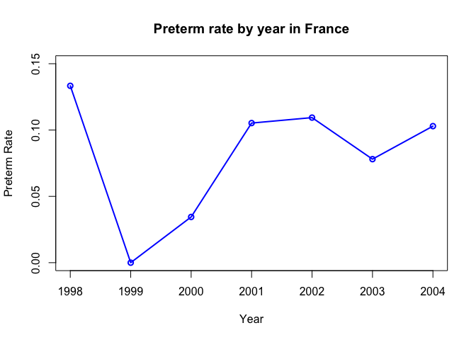

```r
plot(preterm_birth_fr$Year, preterm_birth_fr$preterm_rate,
     type="o",
     main="Preterm rate by year in France",
     ylim=c(0,0.15),
     xlab="Year",
     ylab="Preterm Rate",
     col="blue",
     lwd=2)
```

### **(7)**

#### **Full join the data frame “year_birth_fr” to “preterm_birth_fr” using the common variable “Year”. (Hint: use full_join() in library dplyr)**

```r
year_birth_fr
```

```
## # A tibble: 7 x 3
##    Year count avg_mom_age
## * <int> <int>       <dbl>
## 1  1998    15        27.6
## 2  1999    16        26.4
## 3  2000    29        27.4
## 4  2001    57        26.4
## 5  2002    64        26.2
## 6  2003   206        27.2
## 7  2004   205        27.7
```

```r
preterm_birth_fr
```

```
## # A tibble: 7 x 3
##    Year num_preterm preterm_rate
##   <int>       <dbl>        <dbl>
## 1  1998           2       0.133
## 2  1999           0       0
## 3  2000           1       0.0345
## 4  2001           6       0.105
## 5  2002           7       0.109
## 6  2003          16       0.0780
## 7  2004          21       0.103
```

```r
birth_join = full_join(x=year_birth_fr,
                       y=preterm_birth_fr,
                       by="Year")
birth_join
```

```
## # A tibble: 7 x 5
##    Year count avg_mom_age num_preterm preterm_rate
##   <int> <int>       <dbl>       <dbl>        <dbl>
## 1  1998    15        27.6           2       0.133
## 2  1999    16        26.4           0       0
## 3  2000    29        27.4           1       0.0345
## 4  2001    57        26.4           6       0.105
## 5  2002    64        26.2           7       0.109
## 6  2003   206        27.2          16       0.0780
## 7  2004   205        27.7          21       0.103
```